# Data-Wrangling-project

2023-10-03

## 1. Introduction

### Business Problem

In the ever-competitive grocery market, ensuring that marketing campaigns and promotions not only reach the target audience but also compel them to make purchases is crucial. Regork, a national grocery chain, employs various marketing campaigns and promotions to enhance its market reach and elevate sales. However, the effectiveness of these campaigns and their genuine impact on purchasing behaviors among diverse customer segments remain intricate puzzles.

### Objective

The objective of our analysis is to unravel the nuances of marketing and campaign effectiveness by exploring the relationship between promotional activities, customer demographics, and purchasing behaviors. We intend to delve into questions such as:

- Which campaigns have demonstrated substantial influence on purchasing?
- Are there specific customer demographics that are more responsive to particular campaigns or promotions?
- What products are most often purchased under promotional campaigns?
- Is there a noticeable uplift in sales during and after campaigns?

### Significance

Understanding the dynamics of campaign effectiveness allows Regork to:

1. Allocate marketing budget more judiciously, maximizing ROI.
2. Tailor future campaigns to be more resonant with specific customer segments.
3. Identify and optimize the timing, duration, and featured products of campaigns.
4. Enhance customer engagement and satisfaction by offering relevant promotions.

### Methodology

To navigate through this, we will:

1. Merge transactional data with campaign and product information, creating a consolidated view of customer purchases in relation to promotional campaigns.
2. Perform exploratory data analysis to identify patterns, anomalies, or trends in purchasing behavior during campaigns.
3. Explore customer demographics to understand who is most influenced by campaigns.
4. Evaluate the impact of promotions on sales volumes during and post-campaign periods.

### Implications

Our analysis will pave the way to:

- Forge data-driven marketing strategies that amplify sales and customer engagement.
- Identify opportunities to enhance campaign effectiveness, targeting, and timing.
- Recognize potential areas for growth and further investment in specific product categories or customer segments.

## 2. Packages/Libraries Required

### Load Packages

```r
library(completejourney)
library(tidyverse)
library(lubridate)
library(scales)
library(ggplot2)
library(data.table)
library(gridExtra)
library(scales)


options(warn=-1)
```

### Transactions Data Cleaning

```r
clean_data <- function(data, required_cols){
  data %>%
    select(all_of(required_cols)) %>%
    filter(across(all_of(required_cols), ~!is.na(.))) %>%
    distinct()
}


selected_transactions <- clean_data(transactions, c("household_id", "product_id", "store_id", "quantity", "sales_value", "week", "retail_disc", "coupon_disc", "coupon_match_disc"))
selected_products <- clean_data(products, c("manufacturer_id", "product_id", "department", "product_category", "product_type"))
selected_campaigns <- clean_data(campaigns, c("campaign_id", "household_id"))
selected_coupons <- clean_data(coupons, c("campaign_id", "product_id", "coupon_upc"))
selected_coupon_redemptions <- clean_data(coupon_redemptions, c("campaign_id", "household_id", "coupon_upc","redemption_date"))
selected_demographics <- clean_data(demographics, c("age", "household_id", "income","marital_status","household_size"))



dt_selected_transactions <- as.data.table(selected_transactions)
dt_selected_transactions[, campaign_cost := abs(retail_disc) + abs(coupon_disc) + abs(coupon_match_disc)]
dt_selected_transactions[, net_profit := sales_value - 0.5 * sales_value - campaign_cost]
dt_selected_coupons <- as.data.table(selected_coupons)
dt_selected_campaigns <- as.data.table(selected_campaigns)
dt_selected_coupon_redemptions <- as.data.table(selected_coupon_redemptions)
dt_selected_demographics <- as.data.table(selected_demographics)
dt_selected_campaign_descriptions <- as.data.table(campaign_descriptions)
```

## 1. Which campaigns have demonstrated substantial influence on purchasing?

```r
setDTthreads(threads = getOption("datatable.threads"))
options(datatable.allow.cartesian=TRUE)


analysis_data_with_coupons <- dt_selected_transactions[
  dt_selected_coupon_redemptions,
  on = "household_id",
  nomatch = 0L
]


campaign_impact <- analysis_data_with_coupons[, .(
    total_sales = sum(sales_value, na.rm = TRUE),
    total_transactions = .N,
    avg_sales_per_transaction = mean(sales_value, na.rm = TRUE),
    total_quantity = sum(quantity, na.rm = TRUE)
  ), by = campaign_id
][order(-total_sales)]

campaign_impact <- campaign_impact[
  dt_selected_campaign_descriptions,
  on = "campaign_id"
]


top_campaigns <- head(campaign_impact, 5)


bottom_campaigns <- tail(campaign_impact, 5)
top_campaigns
```

```
##    campaign_id total_sales total_transactions avg_sales_per_transaction
## 1:           1     1714.35                618                  2.774029
## 2:           2    15562.71               6348                  2.451593
## 3:           3     8083.16               2766                  2.922328
## 4:           4    34284.35               9792                  3.501261
## 5:           5    82600.86              21321                  3.874155
##    total_quantity campaign_type start_date   end_date
## 1:            741        Type B 2017-03-03 2017-04-09
## 2:         825016        Type B 2017-03-08 2017-04-09
## 3:         510149        Type C 2017-03-13 2017-05-08
## 4:        1873063        Type B 2017-03-29 2017-04-30
## 5:        5522517        Type B 2017-04-03 2017-05-07
```

```r
bottom_campaigns
```

```
##    campaign_id total_sales total_transactions avg_sales_per_transaction
## 1:          23    27173.03               9168                  2.963899
## 2:          24          NA                 NA                        NA
## 3:          25     4188.81               1301                  3.219685
## 4:          26    85901.15              26388                  3.255311
## 5:          27   238047.27              85025                  2.799733
##    total_quantity campaign_type start_date   end_date
## 1:        1465286        Type B 2017-12-28 2018-02-04
## 2:             NA        Type C 2016-11-14 2017-01-16
## 3:          14720        Type B 2016-12-06 2017-02-05
## 4:        5342286        Type B 2016-12-28 2017-02-19
## 5:        9282453        Type A 2017-02-08 2017-03-26
```

```r
combined_campaigns <- rbind(top_campaigns, bottom_campaigns)

top_campaigns
```

```
##    campaign_id total_sales total_transactions avg_sales_per_transaction
## 1:           1     1714.35                618                  2.774029
## 2:           2    15562.71               6348                  2.451593
## 3:           3     8083.16               2766                  2.922328
## 4:           4    34284.35               9792                  3.501261
## 5:           5    82600.86              21321                  3.874155
##    total_quantity campaign_type start_date   end_date
## 1:            741        Type B 2017-03-03 2017-04-09
## 2:         825016        Type B 2017-03-08 2017-04-09
## 3:         510149        Type C 2017-03-13 2017-05-08
## 4:        1873063        Type B 2017-03-29 2017-04-30
## 5:        5522517        Type B 2017-04-03 2017-05-07
```

```r
bottom_campaigns
```

```
##    campaign_id total_sales total_transactions avg_sales_per_transaction
## 1:          23    27173.03               9168                  2.963899
## 2:          24          NA                 NA                        NA
## 3:          25     4188.81               1301                  3.219685
## 4:          26    85901.15              26388                  3.255311
## 5:          27   238047.27              85025                  2.799733
##    total_quantity campaign_type start_date   end_date
## 1:        1465286        Type B 2017-12-28 2018-02-04
## 2:             NA        Type C 2016-11-14 2017-01-16
## 3:          14720        Type B 2016-12-06 2017-02-05
## 4:        5342286        Type B 2016-12-28 2017-02-19
## 5:        9282453        Type A 2017-02-08 2017-03-26
```

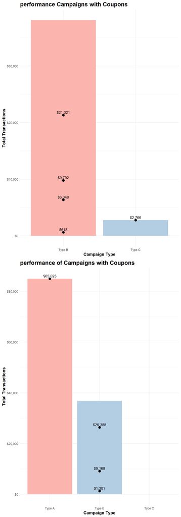

```r
top_transactions_plot <- ggplot(top_campaigns, aes(x = reorder(campaign_type, -total_transactions), y = total_transactions, fill = as.factor(campaign_type))) +
  geom_bar(stat = "identity", show.legend = FALSE) +
  scale_fill_brewer(palette = "Pastel1") +
  labs(title = "performance Campaigns with Coupons",
       x = "Campaign Type",
       y = "Total Transactions") +
  theme_minimal() +
  geom_text(aes(label = scales::dollar(total_transactions)),
            vjust = -0.5,
            col = "black",
            size = 3.5) +
  geom_point(aes(x = reorder(campaign_type, -total_transactions), y = total_transactions),
             color = "black", size = 3, show.legend = FALSE) +
  theme(
    plot.title = element_text(face = "bold", size = 16),  # Title settings
    axis.title.x = element_text(face = "bold", size = 12),  # X-axis label settings
    axis.title.y = element_text(face = "bold", size = 12)  # Y-axis label settings
  ) +
  scale_y_continuous(labels = scales::dollar)





bottom_transactions_plot <- ggplot(bottom_campaigns, aes(x = reorder(campaign_type, -total_transactions), y = total_transactions, fill = as.factor(campaign_type))) +
  geom_bar(stat = "identity", show.legend = FALSE) +
  scale_fill_brewer(palette = "Pastel1") +
  labs(title = "performance of Campaigns with Coupons",
       x = "Campaign Type",
       y = "Total Transactions") +
  theme_minimal() +
  geom_text(aes(label = scales::dollar(total_transactions)),
            vjust = -0.5,
            col = "black",
            size = 3.5) +
  geom_point(aes(x = reorder(campaign_type, -total_transactions), y = total_transactions),
             color = "black", size = 3, show.legend = FALSE)  +
  theme(
    plot.title = element_text(face = "bold", size = 16),  # Title settings
    axis.title.x = element_text(face = "bold", size = 12),  # X-axis label settings
    axis.title.y = element_text(face = "bold", size = 12)  # Y-axis label settings
  )  +
  scale_y_continuous(labels = scales::dollar)


gridExtra::grid.arrange(top_transactions_plot, bottom_transactions_plot, ncol = 1)
```

```r
setDTthreads(threads = getOption("datatable.threads"))
options(datatable.allow.cartesian=TRUE)


analysis_data_without_coupons <- dt_selected_transactions[
  !dt_selected_coupon_redemptions,
  on = "household_id"
][
  dt_selected_demographics,
  on = "household_id",
  nomatch = 0L
][
  dt_selected_campaigns,
  on = .(household_id = household_id),
  nomatch = 0L
]


campaign_impact <- analysis_data_without_coupons[, .(
    total_sales = sum(sales_value, na.rm = TRUE),
    total_transactions = .N,
    avg_sales_per_transaction = mean(sales_value, na.rm = TRUE),
    total_quantity = sum(quantity, na.rm = TRUE)
  ), by = campaign_id
][order(-total_sales)]

campaign_impact <- campaign_impact[
  dt_selected_campaign_descriptions,
  on = "campaign_id"
]


top_campaigns <- head(campaign_impact, 5)


bottom_campaigns <- tail(campaign_impact, 5)


combined_campaigns <- rbind(top_campaigns, bottom_campaigns)

top_campaigns
```

```
##    campaign_id total_sales total_transactions avg_sales_per_transaction
## 1:           1     2087.39                597                  3.496466
## 2:           2    21259.55               6816                  3.119065
## 3:           3     1719.62                916                  1.877314
## 4:           4    79261.78              24326                  3.258315
## 5:           5   138418.59              41712                  3.318436
##    total_quantity campaign_type start_date   end_date
## 1:          31061        Type B 2017-03-03 2017-04-09
## 2:         652110        Type B 2017-03-08 2017-04-09
## 3:           1225        Type C 2017-03-13 2017-05-08
## 4:        3633183        Type B 2017-03-29 2017-04-30
## 5:        6749876        Type B 2017-04-03 2017-05-07
```

```r
bottom_campaigns
```

```
##    campaign_id total_sales total_transactions avg_sales_per_transaction
## 1:          23   234822.67              67598                  3.473811
## 2:          24          NA                 NA                        NA
## 3:          25    12152.00               3716                  3.270183
## 4:          26    97070.79              29532                  3.286970
## 5:          27   242796.84              74149                  3.274445
##    total_quantity campaign_type start_date   end_date
## 1:        9079180        Type B 2017-12-28 2018-02-04
## 2:             NA        Type C 2016-11-14 2017-01-16
## 3:         368387        Type B 2016-12-06 2017-02-05
## 4:        3803289        Type B 2016-12-28 2017-02-19
## 5:        8534045        Type A 2017-02-08 2017-03-26
```

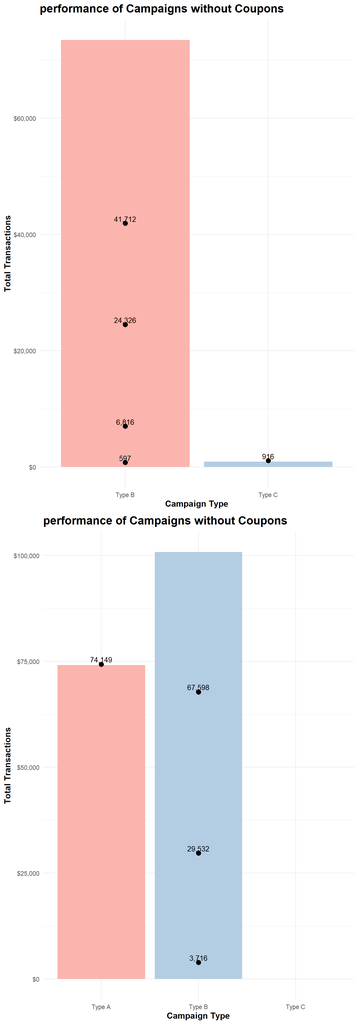

```r
top_transactions_plot <- ggplot(top_campaigns, aes(x = reorder(campaign_type, -total_transactions), y = total_transactions, fill = as.factor(campaign_type))) +
  geom_bar(stat = "identity", show.legend = FALSE) +
  scale_fill_brewer(palette = "Pastel1") +
  labs(title = "performance of Campaigns without Coupons",
       x = "Campaign Type",
       y = "Total Transactions") +
  theme_minimal() +
  geom_text(aes(label = scales::comma(total_transactions)),
            vjust = -0.5,
            col = "black",
            size = 3.5) +
  geom_point(aes(x = reorder(campaign_type, -total_transactions), y = total_transactions + 200),
             color = "black", size = 3, show.legend = FALSE)  +
  theme(
    plot.title = element_text(face = "bold", size = 16),  # Title settings
    axis.title.x = element_text(face = "bold", size = 12),  # X-axis label settings
    axis.title.y = element_text(face = "bold", size = 12)  # Y-axis label settings
  )  +
  scale_y_continuous(labels = scales::dollar)


bottom_transactions_plot <- ggplot(bottom_campaigns, aes(x = reorder(campaign_type, -total_transactions), y = total_transactions, fill = as.factor(campaign_type))) +
  geom_bar(stat = "identity", show.legend = FALSE) +
  scale_fill_brewer(palette = "Pastel1") +
  labs(title = "performance of Campaigns without Coupons",
       x = "Campaign Type",
       y = "Total Transactions") +
  theme_minimal() +
  geom_text(aes(label = scales::comma(total_transactions)),
            vjust = -0.5,
            col = "black",
            size = 3.5) +
  geom_point(aes(x = reorder(campaign_type, -total_transactions), y = total_transactions + 200),
             color = "black", size = 3, show.legend = FALSE)  +
  theme(
    plot.title = element_text(face = "bold", size = 16),  # Title settings
    axis.title.x = element_text(face = "bold", size = 12),  # X-axis label settings
    axis.title.y = element_text(face = "bold", size = 12)  # Y-axis label settings
  )  +
  scale_y_continuous(labels = scales::dollar)


gridExtra::grid.arrange(top_transactions_plot, bottom_transactions_plot, ncol = 1)
```